# NCFH workshop

Simon Forsberg

2024-11-06

## Introduction

In this short tutorial we will analyze some artificial Olink data. The dataset contains protein expression values for 92 proteins in 500 samples. We will attempt to answer the following questions:

1. Are there any proteins whose levels differ between cases and controls?
2. Between disease sub-groups?
3. Between males and females?
4. Do drug treatments have an effect on any of the protein levels?
5. Does age at diagnosis have an effect on any of the above?

We will make use of some basic R-functions, various functions from the tidyverse eco-system of packages, as well as Olinks R-package OlinkAnalyze. Let’s start by loading the packages we will need (if you do not have these packages installed, simply run *install.packages(nameOfPackage)*).

```r
library(tidyverse)
library(broom)
library(OlinkAnalyze)
```

## Load data

When you receive data from Olink, it is in the form of a parquet file that can be read with the function *OlinkAnalyze::read_NPX*. If you have additional files with clinical variables etc, you can then read them into R and join them to the Olink data using for instance the function *dplyr::left_join*.

For this tutorial, we will use a dataset that is already annotated with clinical variables. Since it is not in the standard Olink format, we will read it with the function *read_delim*.

```r
data <- read_delim('dataset/toy_dataset_olink_workshop.csv', delim = ';') %>%
  mutate(across(7:11, as.factor)) # This tells R to treat columns 7 to 11 as factors. This means that they are "dummy variables" identifying discrete groups
```

## Quick look at the data

Let us start with a quick look at how the data is formated.

```r
data
```

```
## # A tibble: 46,000 × 12
##    SampleID Panel UniProt OlinkID  Assay    NPX Clustering phenotype Sex
##    <chr>    <chr> <chr>   <chr>    <chr>  <dbl> <fct>      <fct>     <fct>
##  1 sample_1 CVD   P10145  OID00101 IL-8    10.1 2          2         2
##  2 sample_1 CVD   P15692  OID00102 VEGF-A  17.1 2          2         2
##  3 sample_1 CVD   P35318  OID00103 AM      13.1 2          2         2
##  4 sample_1 CVD   P29965  OID00105 CD40-L  11.4 2          2         2
##  5 sample_1 CVD   Q99988  OID00106 GDF-15  15.9 2          2         2
##  6 sample_1 CVD   P49763  OID00107 PlGF    12.8 2          2         2
##  7 sample_1 CVD   P16581  OID00108 SELE    10.6 2          2         2
##  8 sample_1 CVD   P01133  OID00109 EGF     10.0 2          2         2
##  9 sample_1 CVD   O00300  OID00110 OPG     15.5 2          2         2
## 10 sample_1 CVD   P12931  OID00111 SRC     12.8 2          2         2
## # ℹ 45,990 more rows
## # ℹ 3 more variables: Methotrexate <fct>, Chloroquine <fct>,
## #   Age_at_diagnosis <dbl>
```

Each row in data contains the level of one protein in one sample. The columns UniProt, OlinkID, and Assay tell us which protein by alternative IDs. The column SampleID tells us which sample, and the column NPX contains the protein levels in Olinks unit Normalized Protein Expression. You will find these columns in all Olink data. The last six columns (Clustering, phenotype, Sex, Methotrexate, Chloroquine, Age_at_diagnosis) contain the clinical variables and are specific to this dataset.

To get an overview of the data, we will first do a Principal Component Analysis (PCA). This will project the high dimensional data (92 proteins/dimensions) onto a plane (2 dimensions) for easy visualization. This is a good way to look for global trends in the data.

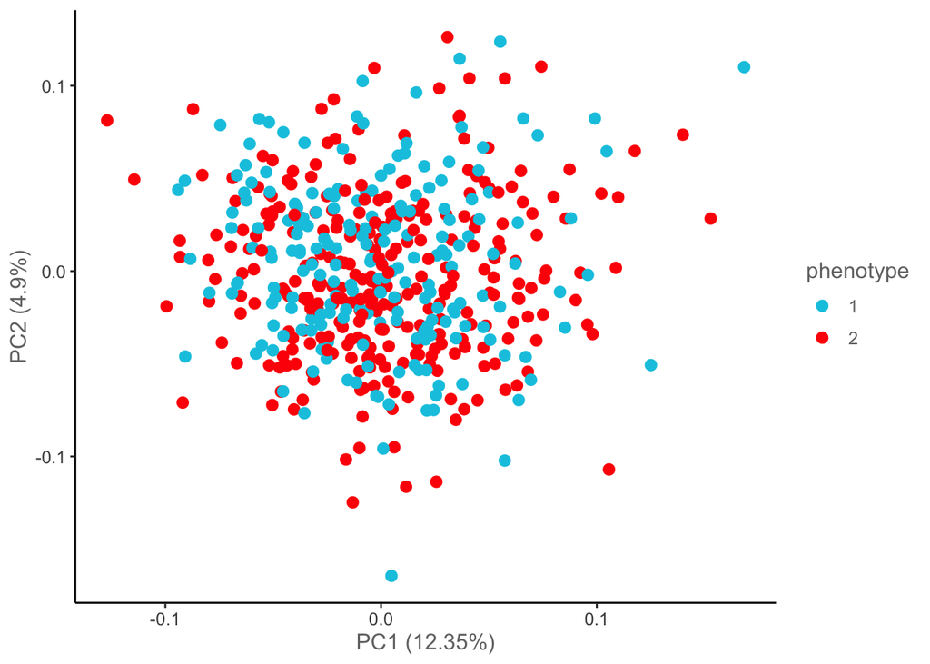

```r
olink_pca_plot(data, color_g = 'phenotype')
```

Each point in this figure represents one sample, and the colors indicate case vs control. No clear separation can be seen between cases and controls. However, remember that this is a “birds eye view” of the data and some proteins might still differ between cases and controls. Try changing the *color_g* argument to color by other variables/traits.

## Cases vs Controls

To see if there are any proteins whose levels differ between cases and controls, we will perform one t-test per protein. This tests if the mean NPX level differs between the two groups. Since we perform 92 different tests, we also need to adjust our p-values accordingly. This can easily be done with the function *olink_ttest* (for a non-paramteric equivalent, try using *olink_wilcox* instead). We will then visualize the t-test results using the function *olink_volcano_plot*.

```r
caseControl_tTest <- olink_ttest(df = data, variable = 'phenotype')
```

```
## T-test is performed on 1 - 2.
```

```r
caseControl_tTest
```

```
## # A tibble: 92 × 16
##    Assay OlinkID UniProt Panel estimate   `1`   `2` statistic  p.value parameter
##    <chr> <chr>   <chr>   <chr>    <dbl> <dbl> <dbl>     <dbl>    <dbl>     <dbl>
##  1 ST2   OID001… Q01638  CVD     -1.56   8.07  9.64     -9.85 6.30e-21      469.
##  2 AM    OID001… P35318  CVD     -0.619 11.7  12.3      -4.93 1.15e- 6      457.
##  3 SRC   OID001… P12931  CVD     -0.573 11.9  12.5      -4.92 1.22e- 6      464.
##  4 SIRT2 OID001… Q8IXJ6  CVD     -0.695  8.37  9.06     -4.51 8.50e- 6      434.
##  5 EGF   OID001… P01133  CVD     -0.527 10.9  11.4      -3.53 4.60e- 4      464.
##  6 CXCL6 OID001… P80162  CVD     -0.422 11.0  11.5      -3.49 5.36e- 4      431.
##  7 OPG   OID001… O00300  CVD     -0.253 14.1  14.3      -2.54 1.13e- 2      420.
##  8 IL-1… OID001… P18510  CVD     -0.250  9.60  9.85     -2.03 4.34e- 2      461.
##  9 CXCL… OID001… Q9H2A7  CVD      0.176  8.58  8.40      1.74 8.31e- 2      440.
## 10 HB-E… OID001… Q99075  CVD      0.153  9.67  9.52      1.57 1.16e- 1      434.
## # ℹ 82 more rows
## # ℹ 6 more variables: conf.low <dbl>, conf.high <dbl>, method <chr>,
## #   alternative <chr>, Adjusted_pval <dbl>, Threshold <chr>
```

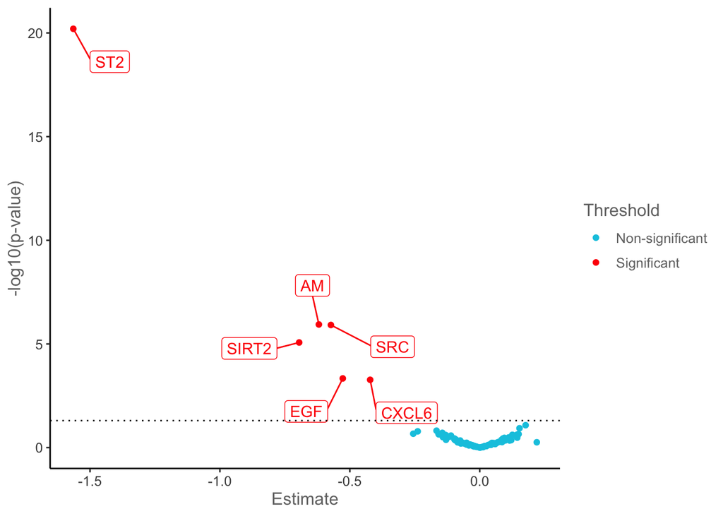

```r
# Visualize in a volcano plot
olink_volcano_plot(caseControl_tTest)
```

The volcano plot shows the mean difference between cases and controls (x-axis) versus the corresponding p-value (y-axis). Each point corresponds to one protein. We can see that after multiple testing adjustment, six proteins differ significantly between cases and controls. To look closer at these proteins, we can use *olink_boxplot* to plot the distributions per protein and sample group in the form of boxplots. We can see that for all of these proteins, the levels are on average higher in patient group 2.

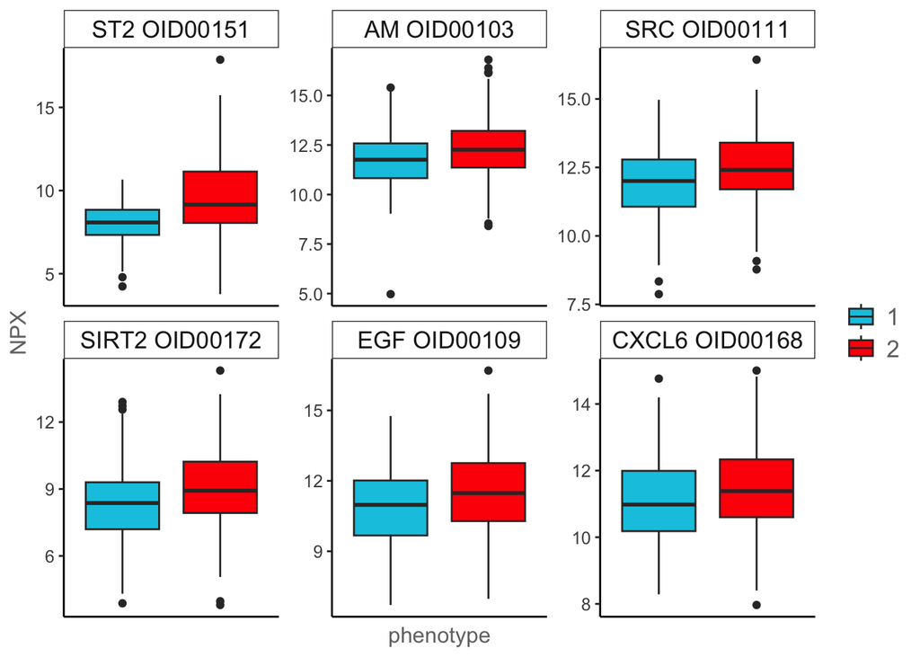

```r
significant <- caseControl_tTest %>%
  filter(Threshold == 'Significant') %>%
  pull(OlinkID)

caseControl_boxplots <- olink_boxplot(df = data, variable = 'phenotype', olinkid_list = significant)
caseControl_boxplots[[1]]
```

## Disease subgroups

```r
diseaseGroup_anova <- olink_anova(df = data, variable = 'Clustering')
```

```
## ANOVA model fit to each assay: NPX~Clustering
```

```r
diseaseGroup_anova
```

```
## # A tibble: 92 × 12
##    Assay  OlinkID  UniProt Panel term        df  sumsq meansq statistic  p.value
##    <chr>  <chr>    <chr>   <chr> <chr>    <dbl>  <dbl>  <dbl>     <dbl>    <dbl>
##  1 ST2    OID00151 Q01638  CVD   Cluster…     4 1.16e3 291.      142.   1.21e-80
##  2 AM     OID00103 P35318  CVD   Cluster…     4 2.10e2  52.5      31.9  1.15e-23
##  3 SRC    OID00111 P12931  CVD   Cluster…     4 1.80e2  44.9      31.3  2.91e-23
##  4 EGF    OID00109 P01133  CVD   Cluster…     4 1.63e2  40.7      15.9  3.14e-12
##  5 SIRT2  OID00172 Q8IXJ6  CVD   Cluster…     4 6.42e1  16.0       5.58 2.13e- 4
##  6 CXCL6  OID00168 P80162  CVD   Cluster…     4 3.01e1   7.53      4.30 1.97e- 3
##  7 AGRP   OID00174 O00253  CVD   Cluster…     4 1.21e1   3.04      1.88 1.12e- 1
##  8 CXCL16 OID00170 Q9H2A7  CVD   Cluster…     4 9.06e0   2.26      1.81 1.25e- 1
##  9 IL-1ra OID00112 P18510  CVD   Cluster…     4 1.36e1   3.40      1.78 1.31e- 1
## 10 KLK6   OID00116 Q92876  CVD   Cluster…     4 9.73e0   2.43      2.10 7.93e- 2
## # ℹ 82 more rows
## # ℹ 2 more variables: Adjusted_pval <dbl>, Threshold <chr>
```

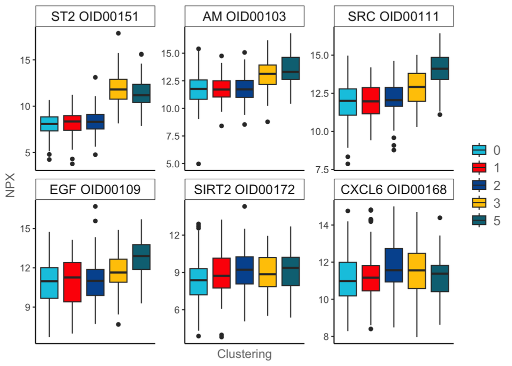

```r
# boxplots of significant proteins
significant <- diseaseGroup_anova %>%
  filter(Threshold == 'Significant') %>%
  pull(OlinkID)

diseaseGroup_boxplots <- olink_boxplot(df = data, variable = 'Clustering', olinkid_list = significant)
diseaseGroup_boxplots[[1]]
```

## Sex differences

To identify proteins that differ significantly between males and females, we will again use *olink_ttest* to perform a t-test per protein. This time, we will tell the function to use the variable “Sex”.

```r
sex_tTest <- olink_ttest(df = data, variable = 'Sex')
```

```
## T-test is performed on 1 - 2.
```

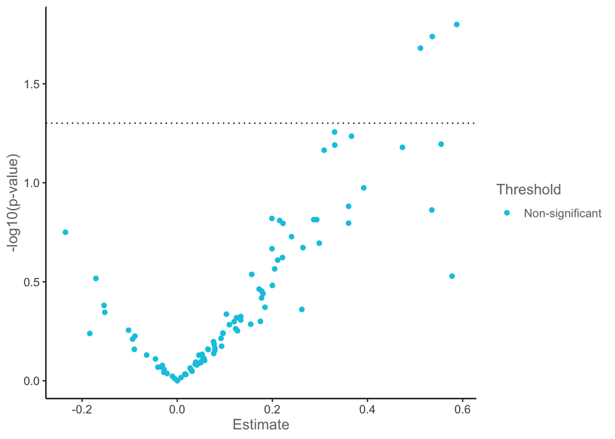

```r
olink_volcano_plot(sex_tTest)
```

In this case, non of the proteins show a significant sex difference.

## Drug treatments

Some of the patients in this study were treated with Methotrexate or Chloroquine. The tretment level, found in the corresponding columns, is indicated as either 0, 1, or 2. We will start by testing if any proteins show differences between these treatment levels. To this end, we will use *olink_anova* to perform an ANOVA per protein and treatment

#### NOTE and warning

R uses the data type *factor* to encode “dummy variables”, where the values identify discrete groups but have no numeric meaning. If a variable contains strings (A, B, C, etc), most R-functions will automatically assume that it is a discrete variable and treat it as a factor. However, it the variable contains numbers, R will typically assume that it is numeric. If numbers are used to label discrete groups, as in this case, you therefore have to convert it to a factor yourself. When loading the data, we did this by applying the function *as.factor* to columns 7-11, ensuring that all downstream functions treat the data accordingly.

```r
Methotrexate_anova <- olink_anova(df = data, variable = 'Methotrexate')
```

```
## Samples removed due to missing variable or covariate levels: sample_1, sample_14, sample_83, sample_130, sample_139, sample_155, sample_189, sample_274, sample_298, sample_299, sample_300, sample_301, sample_302, sample_303, sample_304, sample_305, sample_306, sample_307, sample_308, sample_309, …
```

```
## ANOVA model fit to each assay: NPX~Methotrexate
```

```r
Chloroquine_anova <- olink_anova(df = data, variable = 'Chloroquine')
```

```
## Samples removed due to missing variable or covariate levels: sample_298, sample_299, sample_300, sample_301, sample_302, sample_303, sample_304, sample_305, sample_306, sample_307, sample_308, sample_309, sample_310, sample_311, sample_312, sample_313, sample_314, sample_315, sample_316, sample_3…
```

```
## ANOVA model fit to each assay: NPX~Chloroquine
```

```r
Methotrexate_anova
```

```
## # A tibble: 92 × 12
##    Assay   OlinkID  UniProt Panel term         df sumsq meansq statistic p.value
##    <chr>   <chr>    <chr>   <chr> <chr>     <dbl> <dbl>  <dbl>     <dbl>   <dbl>
##  1 IL-8    OID00101 P10145  CVD   Methotre…     2  31.3  15.7       8.48 2.64e-4
##  2 CHI3L1  OID00150 P36222  CVD   Methotre…     2  22.3  11.2       5.36 5.18e-3
##  3 IL-6    OID00113 P05231  CVD   Methotre…     2  27.3  13.6       4.87 8.29e-3
##  4 TNF-R2  OID00135 P20333  CVD   Methotre…     2  16.9   8.43      4.89 8.18e-3
##  5 TRAIL   OID00120 P50591  CVD   Methotre…     2  14.3   7.16      5.65 3.93e-3
##  6 ECP     OID00196 P12724  CVD   Methotre…     2  14.1   7.07      4.23 1.55e-2
##  7 TNFSF14 OID00138 O43557  CVD   Methotre…     2  12.7   6.33      4.03 1.88e-2
##  8 CXCL6   OID00168 P80162  CVD   Methotre…     2  12.8   6.41      3.78 2.40e-2
##  9 IL-6RA  OID00134 P08887  CVD   Methotre…     2  29.3  14.6       3.50 3.14e-2
## 10 VEGF-A  OID00102 P15692  CVD   Methotre…     2 125.   62.5       3.58 2.92e-2
## # ℹ 82 more rows
## # ℹ 2 more variables: Adjusted_pval <dbl>, Threshold <chr>
```

```r
Chloroquine_anova
```

```
## # A tibble: 92 × 12
##    Assay    OlinkID  UniProt Panel term        df sumsq meansq statistic p.value
##    <chr>    <chr>    <chr>   <chr> <chr>    <dbl> <dbl>  <dbl>     <dbl>   <dbl>
##  1 AGRP     OID00174 O00253  CVD   Chloroq…     2 1.27   0.633    0.426    0.654
##  2 AM       OID00103 P35318  CVD   Chloroq…     2 4.50   2.25     1.07     0.344
##  3 BNP      OID00188 P16860  CVD   Chloroq…     2 6.97   3.48     1.40     0.248
##  4 Beta-NGF OID00153 P01138  CVD   Chloroq…     2 4.21   2.11     2.16     0.118
##  5 CA-125   OID00191 Q8WXI7  CVD   Chloroq…     2 2.46   1.23     0.526    0.592
##  6 CASP-8   OID00184 Q14790  CVD   Chloroq…     2 0.636  0.318    0.231    0.794
##  7 CCL20    OID00190 P78556  CVD   Chloroq…     2 0.224  0.112    0.0489   0.952
##  8 CCL3     OID00166 P10147  CVD   Chloroq…     2 0.988  0.494    0.308    0.735
##  9 CCL4     OID00163 P13236  CVD   Chloroq…     2 3.15   1.58     0.773    0.463
## 10 CD40     OID00176 P25942  CVD   Chloroq…     2 5.19   2.60     1.86     0.157
## # ℹ 82 more rows
## # ℹ 2 more variables: Adjusted_pval <dbl>, Threshold <chr>
```

One protein showed a small but significant difference between the Methotrexate treatment groups. Note that many samples do not have any treatment information (Methotrexate or Chloroquine is NA) and were automatically removed from the analysis.

Next, we will test if the combination of disease subgroup and treatment has an effect on any of the protein levels. To this end, we will fit linear regression models including disease group (the “Clustering” variable), treatment (“Methotrexate” or “Chloroquine”), and the interaction between the two (NPX ~ diseaseGroup + treatment + diseaseGroup*treatment). Such an analysis is also referred to as a two way ANOVA. This is achieved with *olink_anova* by giving the argument *variable* a vector stating the two variables to be analyzed (type *?olink_anova* in the console for further information).

```r
diseaseGroup_Methotrexate_anova <- olink_anova(df = data, variable = c('Clustering', 'Methotrexate'))
```

```
## Samples removed due to missing variable or covariate levels: sample_1, sample_14, sample_83, sample_130, sample_139, sample_155, sample_189, sample_274, sample_298, sample_299, sample_300, sample_301, sample_302, sample_303, sample_304, sample_305, sample_306, sample_307, sample_308, sample_309, …
```

```
## ANOVA model fit to each assay: NPX~Clustering*Methotrexate
```

```r
diseaseGroup_Chloroquine_anova <- olink_anova(df = data, variable = c('Clustering', 'Chloroquine'))
```

```
## Samples removed due to missing variable or covariate levels: sample_298, sample_299, sample_300, sample_301, sample_302, sample_303, sample_304, sample_305, sample_306, sample_307, sample_308, sample_309, sample_310, sample_311, sample_312, sample_313, sample_314, sample_315, sample_316, sample_3…
```

```
## ANOVA model fit to each assay: NPX~Clustering*Chloroquine
```

```r
diseaseGroup_Chloroquine_anova
```

```
## # A tibble: 276 × 12
##    Assay      OlinkID  UniProt Panel term     df sumsq meansq statistic  p.value
##    <chr>      <chr>    <chr>   <chr> <chr> <dbl> <dbl>  <dbl>     <dbl>    <dbl>
##  1 ST2        OID00151 Q01638  CVD   Clus…     3 803.  268.      108.   1.06e-46
##  2 AM         OID00103 P35318  CVD   Clus…     3 171.   57.2      37.6  1.62e-20
##  3 SRC        OID00111 P12931  CVD   Clus…     3 130.   43.4      31.1  1.99e-17
##  4 EGF        OID00109 P01133  CVD   Clus…     3 123.   41.0      15.4  2.68e- 9
##  5 NT-pro-BNP OID00195 <NA>    CVD   Clus…     6  71.3  11.9       4.62 1.70e- 4
##  6 CX3CL1     OID00186 P78423  CVD   Clus…     6  28.3   4.71      3.54 2.16e- 3
##  7 CHI3L1     OID00150 P36222  CVD   Clus…     6  37.4   6.23      3.04 6.80e- 3
##  8 PlGF       OID00107 P49763  CVD   Clus…     6  23.6   3.93      2.69 1.47e- 2
##  9 AGRP       OID00174 O00253  CVD   Clus…     3  13.8   4.59      3.17 2.48e- 2
## 10 CD40-L     OID00105 P29965  CVD   Clus…     6  35.3   5.88      2.49 2.32e- 2
## # ℹ 266 more rows
## # ℹ 2 more variables: Adjusted_pval <dbl>, Threshold <chr>
```

The column *term* in the output tells us if the result refers to disease group, treatment, or the interaction effect. In this case, we are interested in the interaction effects, labeled as “Clustering:Chloroquine” and “Clustering:Methotrexate”. Only NT-pro-BNP shows a significant disease-by-treatment interaction effect. We can visualize this in boxplots, with disaese group on the x-axis and color corresponding to Chloroquine treatment. In this case, the interaction effect (different Chloroquine effects in different disease groups) does not appear to be very striking, in line with the relatively modest p-value.

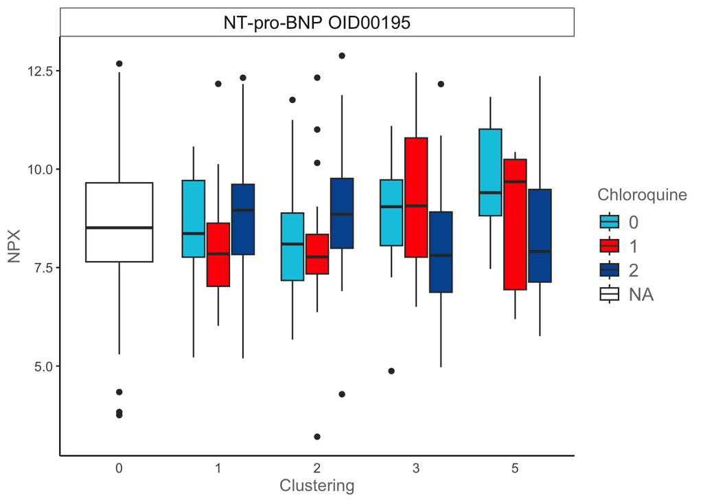

```r
## boxplots
significant <- diseaseGroup_Chloroquine_anova %>%
  filter(Threshold == 'Significant',
         term == 'Clustering:Chloroquine') %>%
  pull(OlinkID)

diseaseGroup_Chloroquine_boxplots <- olink_boxplot(df = data,
                                                   variable = c('Clustering', 'Chloroquine'),
                                                   olinkid_list = significant)
diseaseGroup_Chloroquine_boxplots[[1]]
```

## Age at diagnosis

Lastly, we will investigate if age at diagnosis has an impact (found in the column Age_at_diagnosis). We will start by fitting the following linear regression model per protein: NPX ~ Age_at_diagnosis. Since Age_at_diagnosis is a continuous variable, we can not use *olink_anova* for this. Instead, we will use the R-function *lm*. To apply it to each protein in turn and tidy up the output, we will use some convenient tidyverse functions such as *dplyr::group_by* and *broom::tidy*.

```r
age_lm <- data %>%
  group_by(OlinkID, Assay) %>%
  reframe(tidy(lm(NPX ~ Age_at_diagnosis))) %>%
  filter(term != '(Intercept)') %>%
  arrange(p.value) %>%
  mutate(adjPvalue = p.adjust(p.value, method = 'fdr'),
         Threshold = ifelse(adjPvalue < .05, 'Significant', 'Non-significant'))

age_lm
```

```
## # A tibble: 92 × 9
##    OlinkID  Assay term  estimate std.error statistic p.value adjPvalue Threshold
##    <chr>    <chr> <chr>    <dbl>     <dbl>     <dbl>   <dbl>     <dbl> <chr>
##  1 OID00151 ST2   Age_…  0.0429    0.00861      4.98 1.11e-6  0.000102 Signific…
##  2 OID00182 MMP-… Age_…  0.0158    0.00549      2.88 4.22e-3  0.194    Non-sign…
##  3 OID00114 CSTB  Age_…  0.0132    0.00527      2.51 1.26e-2  0.385    Non-sign…
##  4 OID00187 FABP4 Age_…  0.0119    0.00527      2.26 2.42e-2  0.487    Non-sign…
##  5 OID00180 IL-4  Age_…  0.00788   0.00353      2.23 2.65e-2  0.487    Non-sign…
##  6 OID00168 CXCL6 Age_… -0.0101    0.00508     -1.99 4.73e-2  0.644    Non-sign…
##  7 OID00122 TIE2  Age_…  0.00818   0.00414      1.98 4.90e-2  0.644    Non-sign…
##  8 OID00165 RAGE  Age_…  0.00776   0.00426      1.82 6.94e-2  0.748    Non-sign…
##  9 OID00158 MB    Age_…  0.00852   0.00532      1.60 1.10e-1  0.748    Non-sign…
## 10 OID00167 MMP-7 Age_…  0.00745   0.00472      1.58 1.16e-1  0.748    Non-sign…
## # ℹ 82 more rows
```

Only the protein ST2 shows a significant association to Age_at_diagnosis. We can plot NPX vs Age_at_diagnosis for this protein using ggplot. Although significant, the association appear to be modest.

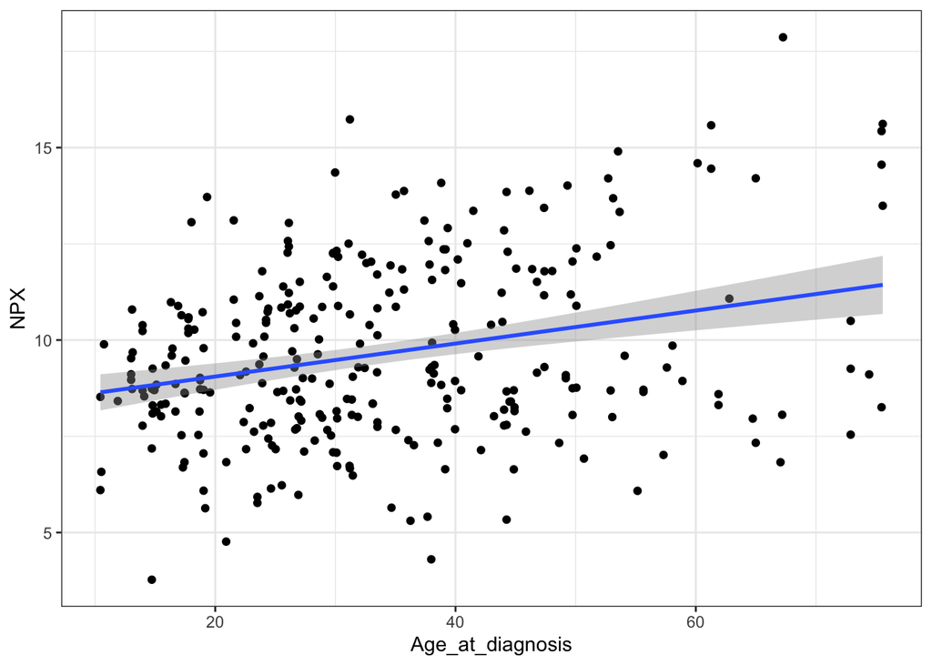

```r
data %>%
  filter(OlinkID == 'OID00151') %>%
  ggplot(aes(x = Age_at_diagnosis, y = NPX)) +
  geom_point() +
  geom_smooth(method = 'lm') +
  theme_bw()
```

Could it be that the strength of the association to Age_at_diagnosis differs between disease groups? To test this, we will fit regression models including disease group, Age_at_diagnosis, and the interaction between the two (NPX ~ diseaseGroup + Age_at_diagnosis + diseaseGroup*Age_at_diagnosis). These allows for a separate NPX vs Age_at_diagnosis slope in every disease group, and a significant interaction means that the slopes differ. In other words, the association to Age_at_diagnosis differs between the groups.

```r
age_diseaseGroup_lm <- data %>%
  group_by(OlinkID, Assay) %>%
  reframe(tidy(lm(NPX ~ Age_at_diagnosis*Clustering))) %>%
  filter(term != '(Intercept)') %>%
  arrange(p.value) %>%
  mutate(adjPvalue = p.adjust(p.value, method = 'fdr'),
         Threshold = ifelse(adjPvalue < .05, 'Significant', 'Non-significant'))
age_diseaseGroup_lm
```

```
## # A tibble: 644 × 9
##    OlinkID  Assay term  estimate std.error statistic p.value adjPvalue Threshold
##    <chr>    <chr> <chr>    <dbl>     <dbl>     <dbl>   <dbl>     <dbl> <chr>
##  1 OID00151 ST2   Age_…   0.0806    0.0138      5.84 1.43e-8   9.19e-6 Signific…
##  2 OID00151 ST2   Age_…   0.0819    0.0175      4.68 4.36e-6   1.41e-3 Signific…
##  3 OID00103 AM    Clus…   2.17      0.603       3.60 3.74e-4   8.03e-2 Non-sign…
##  4 OID00109 EGF   Clus…   2.58      0.783       3.30 1.10e-3   1.76e-1 Non-sign…
##  5 OID00168 CXCL6 Clus…   1.46      0.460       3.17 1.69e-3   2.17e-1 Non-sign…
##  6 OID00149 REN   Age_…   0.0559    0.0190      2.94 3.51e-3   3.77e-1 Non-sign…
##  7 OID00103 AM    Clus…   1.39      0.488       2.84 4.77e-3   4.39e-1 Non-sign…
##  8 OID00124 TNF-… Clus…   1.20      0.462       2.60 9.77e-3   6.32e-1 Non-sign…
##  9 OID00168 CXCL6 Age_…  -0.0328    0.0127     -2.59 1.02e-2   6.32e-1 Non-sign…
## 10 OID00111 SRC   Clus…   1.47      0.571       2.56 1.08e-2   6.32e-1 Non-sign…
## # ℹ 634 more rows
```

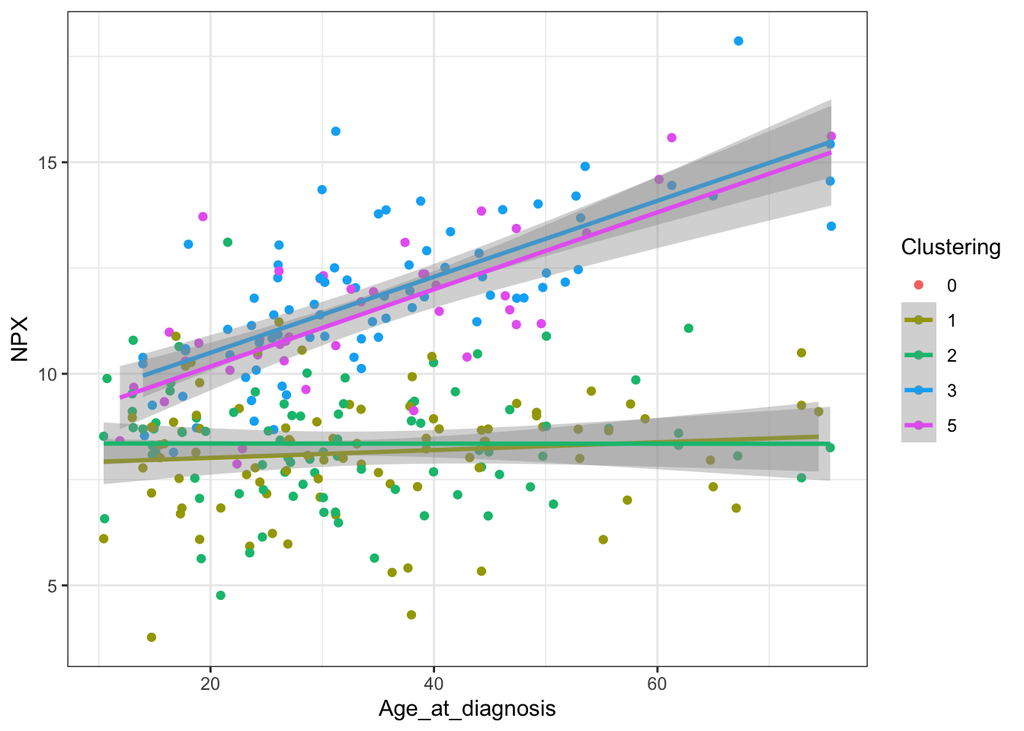

```r
# Plot
data %>%
  filter(OlinkID == 'OID00151') %>%
  ggplot(aes(x = Age_at_diagnosis, y = NPX, colour = Clustering)) +
  geom_point() +
  geom_smooth(method = 'lm') +
  theme_bw()
```

This analysis reveals that ST2 has a strong interaction effect between Age_at_diagnosis and disease group. By plotting NPX vs Age_at_diagnosis, with a separate slope per disease group, we clearly see why. It appears like ST2 levels and Age_at_diagnosis is associated in disease groups 3&5, but not in the other groups.